# Coursera Project: Machine Learning

Deepak

May 29, 2016

# Executive Summary

- **Subject Matter:** In this project, goal is to use data from accelerometers on the belt, forearm, arm, and dumbell of 6 participants and build a prediction model that accurately tells how well they do it. They were asked to perform barbell lifts correctly and incorrectly in 5 different ways.
- **Model Used For Prediction:** Since our goal is prediction and that requires high accuracy, because if someone performing the exercise badly and our outcome says he/she not then it leads to injury. Random forest statistical learning method is used for this task as it provide high accuracy with less interpretability.

## Model Building Exercise Using Random Forest

### Step 1: Loading Necessary R packages

```r
library(caret)
library(tree)
library(randomForest)

Activity<-read.csv("pml-training.csv",header = T) ##Loading Training Data
final_test<-read.csv("pml-testing.csv",header = T) ##Loading Test Data
```

### Step 2: Performing Data Cleaning And Creating Data Partition

```r
selcols<-grep("^((gyros)|(accel)|(magnet)|(roll)|(pitch)|(yaw))",names(Activity))

Activity_F<-Activity[,selcols] ##Selecting the columns With Non=NAs

Activity_F$classe<-Activity$classe ##Adding Class Variable

train<-createDataPartition(Activity_F$classe,p=0.7,list = F) ##Creating Index For data partition
Activity_train<-Activity_F[train,]
Activity_test<-Activity_F[-train,]
```

### Step 3: Performing Cross Validation To Identify Optimum number of Variables With Low Test Error. As you can notice in the below plot, 6 predictors can be used in our Final Model that has low CV error

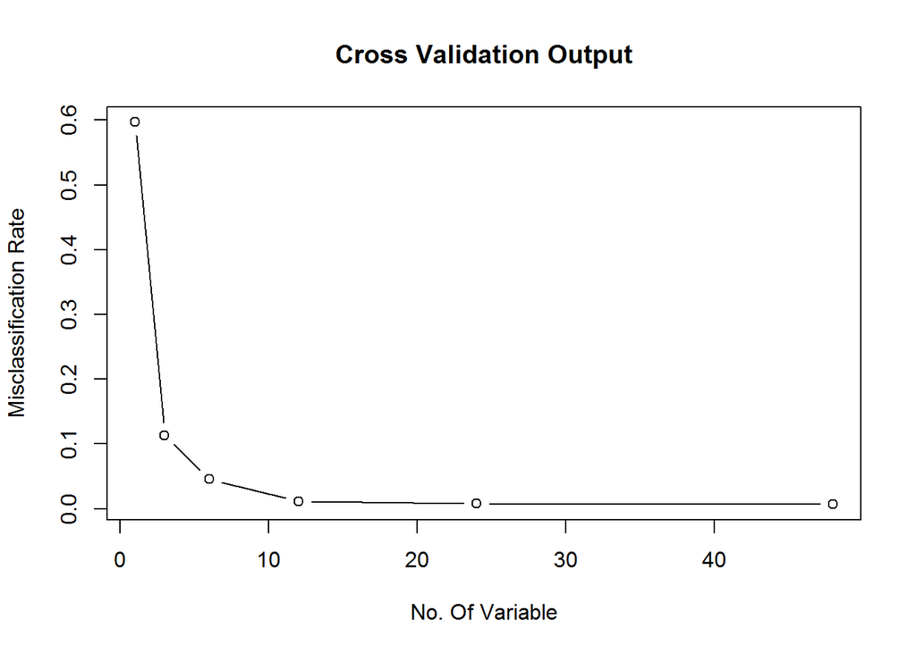

```r
activity.cv<-rfcv(Activity_train[,-49],Activity_train[,49])

plot(activity.cv$n.var,activity.cv$error.cv,xlab = "No. Of Variable",
     ylab = "Misclassification Rate",main = "Cross Validation Output",type = "b")
```

### Step 4: First we train our model with all predictors and see which variables are most important, we also look at the OOB error and Other Parameters

```r
forest.ac<-randomForest(classe~.,data = Activity_train,importance = T)
forest.ac
```

```
##
## Call:
##  randomForest(formula = classe ~ ., data = Activity_train, importance = T)
##                Type of random forest: classification
##                      Number of trees: 500
## No. of variables tried at each split: 6
##
##         OOB estimate of  error rate: 0.47%
## Confusion matrix:
##      A    B    C    D    E  class.error
## A 3904    2    0    0    0 0.0005120328
## B   11 2643    4    0    0 0.0056433409
## C    0   19 2373    4    0 0.0095993322
## D    0    0   18 2233    1 0.0084369449
## E    0    0    1    4 2520 0.0019801980
```

```r
top6<-importance(forest.ac, sort = TRUE)
top6<-top6[order(top6, decreasing=TRUE),drop = FALSE]
top6[1:6,drop = FALSE]
```

```
## [1] 912.4876 637.9250 562.1843 537.3976 483.4325 479.9454
```

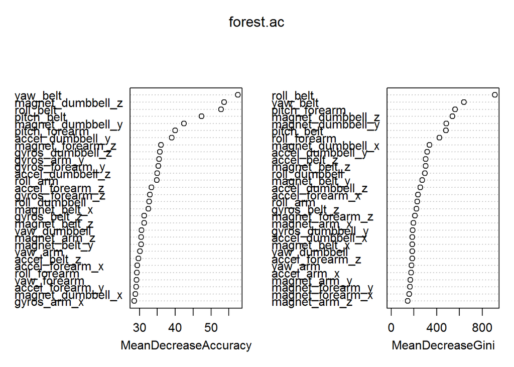

```r
varImpPlot(forest.ac,sort = TRUE)
```

### Step 5: Now we train our final model using top 6 variables and also evaluate the model on the test data to check the accuracy

```r
Activity_train6<-Activity_train[,grep("^((roll_belt)|(yaw_belt)|(pitch_forearm)|(magnet_dumbbell_z)|(magnet_dumbbell_y)|(pitch_belt))",names(Activity_train))]
Activity_train6$classe<-Activity_train$classe


forest.acfinal<-randomForest(classe~.,data = Activity_train6)
forest.pred<-predict(forest.acfinal,newdata = Activity_test,type = "class")
confusionMatrix(forest.pred,Activity_test$classe)
```

```
## Confusion Matrix and Statistics
##
##           Reference
## Prediction    A    B    C    D    E
##          A 1652   11    4    4    0
##          B    4 1099    7    0    5
##          C   10   20 1005    7    1
##          D    7    8   10  950    2
##          E    1    1    0    3 1074
##
## Overall Statistics
##
##                Accuracy : 0.9822
##                  95% CI : (0.9784, 0.9854)
##     No Information Rate : 0.2845
##     P-Value [Acc > NIR] : < 2.2e-16
##
##                   Kappa : 0.9774
##  Mcnemar's Test P-Value : 0.003343
##
## Statistics by Class:
##
##                      Class: A Class: B Class: C Class: D Class: E
## Sensitivity            0.9869   0.9649   0.9795   0.9855   0.9926
## Specificity            0.9955   0.9966   0.9922   0.9945   0.9990
## Pos Pred Value         0.9886   0.9857   0.9636   0.9724   0.9954
## Neg Pred Value         0.9948   0.9916   0.9957   0.9971   0.9983
## Prevalence             0.2845   0.1935   0.1743   0.1638   0.1839
## Detection Rate         0.2807   0.1867   0.1708   0.1614   0.1825
## Detection Prevalence   0.2839   0.1895   0.1772   0.1660   0.1833
## Balanced Accuracy      0.9912   0.9808   0.9859   0.9900   0.9958
```

```r
forest.pred1<-predict(forest.acfinal,newdata = final_test,type = "class")
forest.pred1 ##Predictions On Final Test data with 20 responses using final trimmed model
```

```
##  1  2  3  4  5  6  7  8  9 10 11 12 13 14 15 16 17 18 19 20
##  B  A  B  A  A  E  D  B  A  A  B  C  B  A  E  E  A  B  B  B
## Levels: A B C D E
```